# Supervised Learning: Decision Trees

Ismael Isak

2022-12-27

# Decision Trees

## Regression Trees

Growing a regression tree using annonymous company employee data available on Github.

```r
cp <- read.csv("~/GitHub/R-Pubs-Projects/Data/company2.csv")
```

We will predict the employees’ salaries based on the following independent variables:

gender, education level, job and job time

```r
require(rpart)
```

```r
require(rpart.plot)
```

Create the training set and the test set

```r
i1 <- sample(474, 237)

cp_train <- cp[i1, 1:5]

cp_test <- cp[-i1, 1:5]
```

Grow the regression tree with the rpart() function. The method parameter must be set to “anova”

The rpart() function has built-in cross validation. It performs a 10-fold cross-validation

```r
fit1 <- rpart(salary~., data = cp_train, method = "anova")
```

Plot the tree with the prp() function

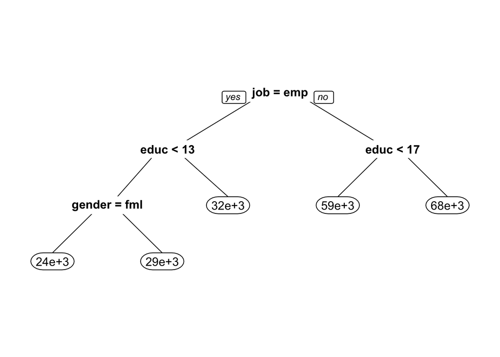

```r
prp(fit1)
```

Plot the tree with the rpart.plot() function

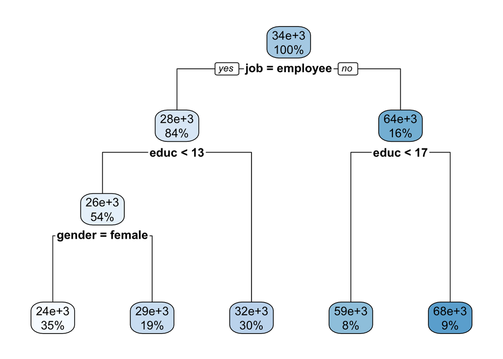

```r
rpart.plot(fit1)
```

Print the complexity parameter table

```r
printcp(fit1)
```

```
##
## Regression tree:
## rpart(formula = salary ~ ., data = cp_train, method = "anova")
##
## Variables actually used in tree construction:
## [1] educ   gender job
##
## Root node error: 6.1759e+10/237 = 260585007
##
## n= 237
##
##         CP nsplit rel error  xerror     xstd
## 1 0.689880      0   1.00000 1.00891 0.165939
## 2 0.030626      1   0.31012 0.31307 0.049974
## 3 0.013541      2   0.27949 0.29572 0.053197
## 4 0.010345      3   0.26595 0.30872 0.060556
## 5 0.010000      4   0.25561 0.30353 0.060350
```

Compute the goodness-of-fit in the training set

```r
pred1 <- predict(fit1, cp_train)

pred1[1:10]
```

```
##       19      191       75       16       36      268      134      184
## 32103.57 23993.49 23993.49 32103.57 23993.49 28672.67 23993.49 23993.49
##      160      252
## 23993.49 32103.57
```

```r
mse1 <- sum((pred1 - cp_train$salary)^2)/237

var1.y <- sum((cp_train$salary - mean(cp_train$salary))^2)/236

rsq1 <- 1 - mse1/var1.y

rsq1
```

```
## [1] 0.7454698
```

Compute the goodness-of-fit in the TEST set

```r
pred2 <- predict(fit1, cp_test)

mse2 <- sum((pred2 - cp_test$salary)^2)/237

var2.y <- sum((cp_test$salary - mean(cp_test$salary))^2)/236

rsq2 <- 1 - mse2/var2.y

rsq2
```

```
## [1] 0.7023751
```

## Classification Tree

Growing a classification tree

```r
phone <- read.csv("~/Desktop/BUAN 6356/Data/phone.csv")
```

We will predict whether a customer will abandon the company the target variable is churn (1 - yes, 0 - no) and the predictors are tenure, age, income, education and family members

```r
require(rpart)

require(rpart.plot)
```

Create the training set and the test set

```r
i2 <- sample(1000, 500)

phone_train <- phone[i2,]

phone_test <- phone[-i2,]
```

Grow the classification tree with the rpart() function. The method parameter must be set to “class”

```r
fit2 <- rpart(churn~., data = phone_train, method = "class")
```

Plot the tree

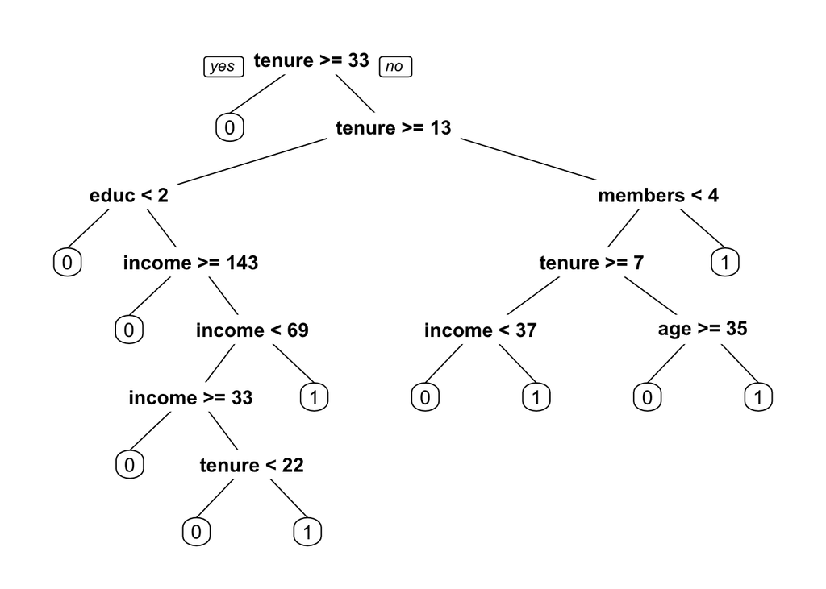

```r
prp(fit2)
```

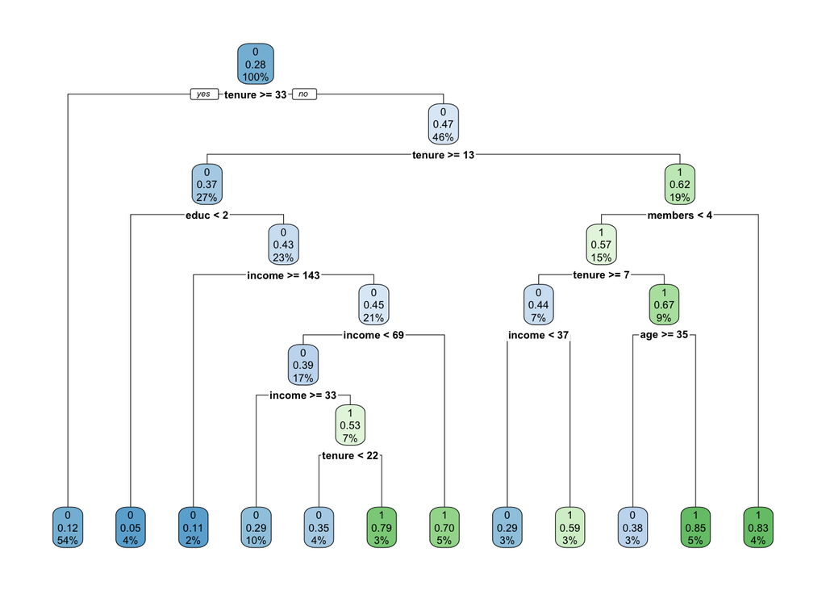

```r
rpart.plot(fit2)
```

Print the CP table

```r
printcp(fit2)
```

```
##
## Classification tree:
## rpart(formula = churn ~ ., data = phone_train, method = "class")
##
## Variables actually used in tree construction:
## [1] age     educ    income  members tenure
##
## Root node error: 140/500 = 0.28
##
## n= 500
##
##         CP nsplit rel error  xerror     xstd
## 1 0.082143      0   1.00000 1.00000 0.071714
## 2 0.021429      2   0.83571 0.83571 0.067621
## 3 0.019048      7   0.71429 0.85000 0.068018
## 4 0.010000     11   0.63571 0.82143 0.067215
```

Compute the predictive accuracy in the training set. The type parameter must be set to “class”

```r
pred3 <- predict(fit2, phone_train, type = "class")

mean(pred3 == phone_train$churn)
```

```
## [1] 0.822
```

Compute the predictive accuracy in the test set

```r
pred4 <- predict(fit2, phone_test, type = "class")

mean(pred4 == phone_test$churn)
```

```
## [1] 0.72
```

## Prune Regression

```r
pred1 <- predict(fit1, cp_train)

pred1[1:10]
```

```
##       19      191       75       16       36      268      134      184
## 32103.57 23993.49 23993.49 32103.57 23993.49 28672.67 23993.49 23993.49
##      160      252
## 23993.49 32103.57
```

```r
mse1 <- sum((pred1 - cp_train$salary)^2)/237

var1.y <- sum((cp_train$salary - mean(cp_train$salary))^2)/236

rsq1 <- 1 - mse1/var1.y

rsq1
```

```
## [1] 0.7454698
```

Print the complexity parameter table to identify the lower cross-validation error

```r
printcp(fit1)
```

```
##
## Regression tree:
## rpart(formula = salary ~ ., data = cp_train, method = "anova")
##
## Variables actually used in tree construction:
## [1] educ   gender job
##
## Root node error: 6.1759e+10/237 = 260585007
##
## n= 237
##
##         CP nsplit rel error  xerror     xstd
## 1 0.689880      0   1.00000 1.00891 0.165939
## 2 0.030626      1   0.31012 0.31307 0.049974
## 3 0.013541      2   0.27949 0.29572 0.053197
## 4 0.010345      3   0.26595 0.30872 0.060556
## 5 0.010000      4   0.25561 0.30353 0.060350
```

To prune the tree we use the prune() function this function has two main arguments: the tree (fit) and the complexity parameter value

Extract the cp value corresponding to the lowest cross-validation error (xerror)

```r
ocp <- fit1$cptable[which.min(fit1$cptable[,"xerror"]),"CP"]

ocp
```

```
## [1] 0.01354073
```

### Prune the tree

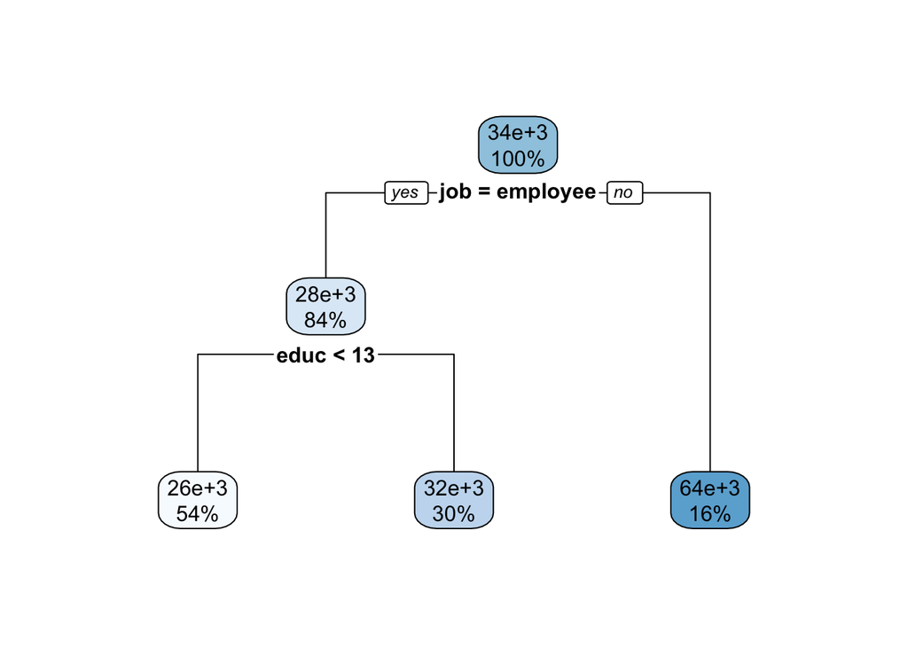

```r
prfit <- prune(fit1, ocp)

rpart.plot(prfit)
```

### Compute the prediction accuracy for our simplified tree

```r
prpred <- predict(prfit, cp_test)

mse <- sum((prpred - cp_test$salary)^2)/237

var.y <- sum((cp_test$salary - mean(cp_test$salary))^2)/236

pr_rsq <- 1 - mse/var.y

pr_rsq
```

```
## [1] 0.6454298
```

### Prune with a particular cp value to see whether we can get a good prediction accuracy with a less complex tree

```r
printcp(fit1)
```

```
##
## Regression tree:
## rpart(formula = salary ~ ., data = cp_train, method = "anova")
##
## Variables actually used in tree construction:
## [1] educ   gender job
##
## Root node error: 6.1759e+10/237 = 260585007
##
## n= 237
##
##         CP nsplit rel error  xerror     xstd
## 1 0.689880      0   1.00000 1.00891 0.165939
## 2 0.030626      1   0.31012 0.31307 0.049974
## 3 0.013541      2   0.27949 0.29572 0.053197
## 4 0.010345      3   0.26595 0.30872 0.060556
## 5 0.010000      4   0.25561 0.30353 0.060350
```

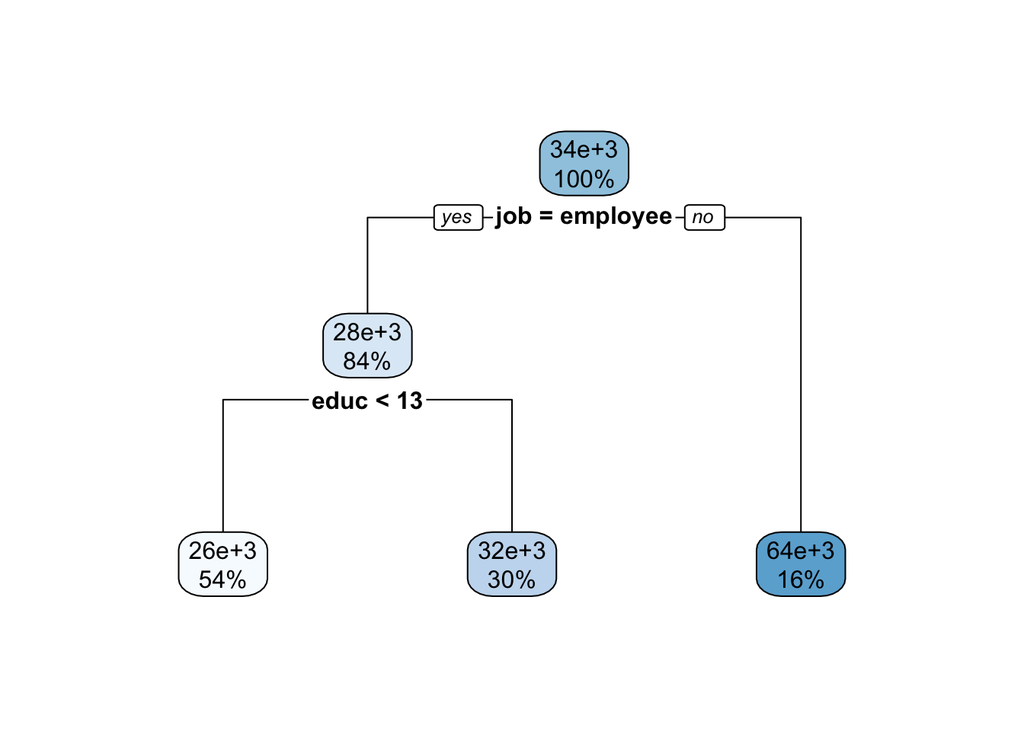

```r
prfit2 <- prune(fit1, 0.03)

rpart.plot(prfit2)
```

### Get the predicted values and compute the r squared

```r
prpred2 <- predict(prfit2, cp_test)

mse <- sum((prpred2 - cp_test$salary)^2)/237

var.y <- sum((cp_test$salary - mean(cp_test$salary))^2)/236

rsq <- 1 - mse/var.y

rsq
```

```
## [1] 0.6454298
```